# IODS course project

## Principal Component Analysis (PCA)

PCA can be used to determine which covariates contributes most to the variation. First, we do an experiment. We run PCA on unscaled **human** data set and create a biplot of the first two components.

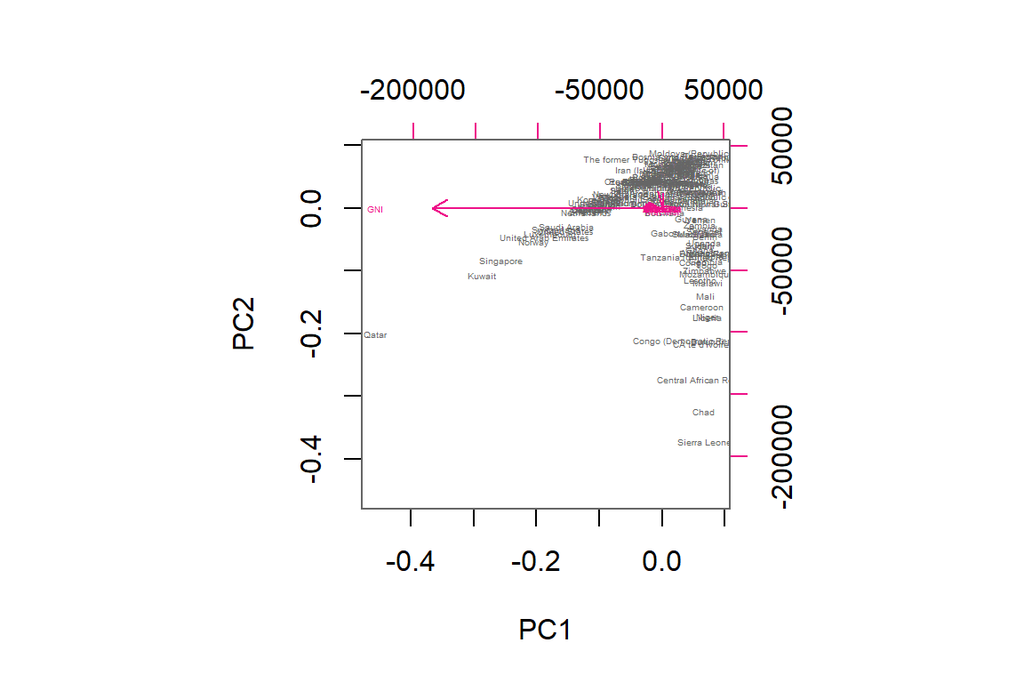

```r
#' non-standardized data
pca_human <- prcomp(human)


# draw a biplot of the principal component representation and the original variables
biplot(pca_human, choices = 1:2, cex = c(0.3,0.3), col = c("grey40", "deeppink2"))
```

The resulting biplot is highly influence by ***GNI**. This is because **GNI** values are very high (range from 581 to 123124) compared to the other covariates such as **Edu2.FM** (range: 0.1717172 - 1.496732).

It is important to scale the data especially if they are from different measurements and units. Standardization ensure that covariates with high value influence the overall pattern.

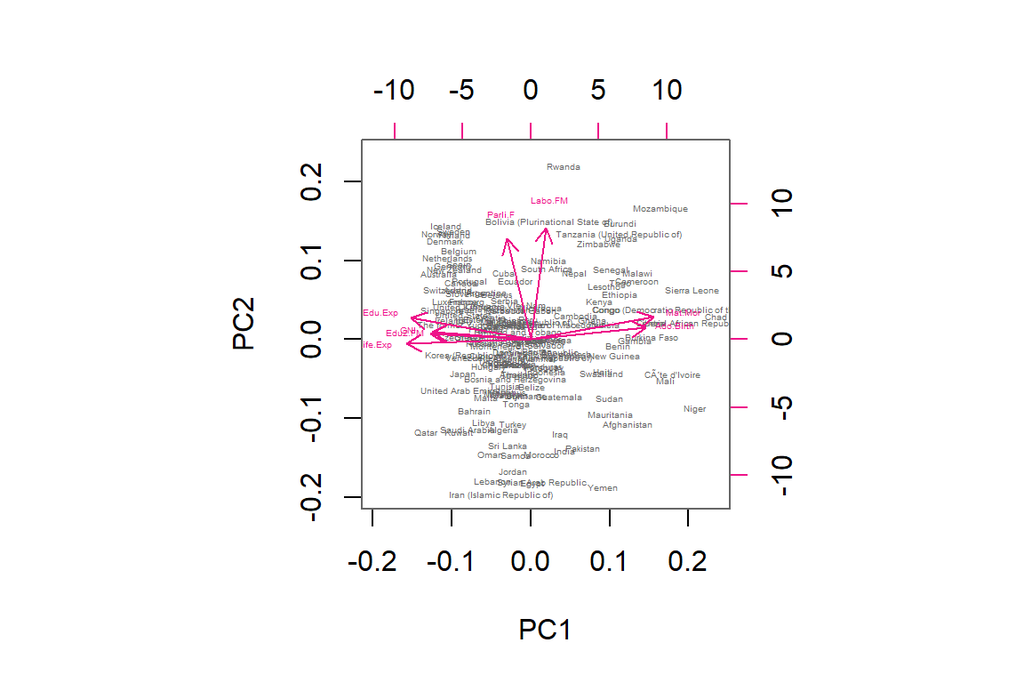

```r
#' standard data
human_std <- scale(human)

#' pca of data_std
pca_stdHuman <- prcomp(human_std)

#'bi-plot
biplot(pca_stdHuman, choices = 1:2, cex = c(0.3,0.3), col = c("grey40", "deeppink2"))
```

```r
summary(pca_stdHuman)
```

```
## Importance of components:
##                           PC1    PC2     PC3     PC4     PC5     PC6     PC7
## Standard deviation     2.0708 1.1397 0.87505 0.77886 0.66196 0.53631 0.45900
## Proportion of Variance 0.5361 0.1624 0.09571 0.07583 0.05477 0.03595 0.02634
## Cumulative Proportion  0.5361 0.6984 0.79413 0.86996 0.92473 0.96069 0.98702
##                            PC8
## Standard deviation     0.32224
## Proportion of Variance 0.01298
## Cumulative Proportion  1.00000
```

The first two PCs can explain ~ 70 % of the total variation among the countries based on the PCA on standardized **Human** data set.

```r
pca_stdHuman
```

```
## Standard deviations (1, .., p=8):
## [1] 2.0708380 1.1397204 0.8750485 0.7788630 0.6619563 0.5363061 0.4589994
## [8] 0.3222406
##
## Rotation (n x k) = (8 x 8):
##                   PC1         PC2         PC3         PC4        PC5
## Edu2.FM   -0.35664370  0.03796058 -0.24223089  0.62678110 -0.5983585
## Labo.FM    0.05457785  0.72432726 -0.58428770  0.06199424  0.2625067
## Edu.Exp   -0.42766720  0.13940571 -0.07340270 -0.07020294  0.1659678
## Life.Exp  -0.44372240 -0.02530473  0.10991305 -0.05834819  0.1628935
## GNI       -0.35048295  0.05060876 -0.20168779 -0.72727675 -0.4950306
## Mat.Mor    0.43697098  0.14508727 -0.12522539 -0.25170614 -0.1800657
## Ado.Birth  0.41126010  0.07708468  0.01968243  0.04986763 -0.4672068
## Parli.F   -0.08438558  0.65136866  0.72506309  0.01396293 -0.1523699
##                   PC6         PC7         PC8
## Edu2.FM    0.17713316  0.05773644  0.16459453
## Labo.FM   -0.03500707 -0.22729927 -0.07304568
## Edu.Exp   -0.38606919  0.77962966 -0.05415984
## Life.Exp  -0.42242796 -0.43406432  0.62737008
## GNI        0.11120305 -0.13711838 -0.16961173
## Mat.Mor    0.17370039  0.35380306  0.72193946
## Ado.Birth -0.76056557 -0.06897064 -0.14335186
## Parli.F    0.13749772  0.00568387 -0.02306476
```